```python
import warnings
warnings.filterwarnings('ignore')

import pandas as pd
import numpy as np
import matplotlib.pyplot as plt
import seaborn as sns
from collections import Counter
from sklearn.linear_model import LinearRegression
from sklearn.preprocessing import PolynomialFeatures
from sklearn.metrics import r2_score, mean_squared_error

# Paleta solar global para coherencia visual
PALETA_SOLAR = 'YlOrBr'
plt.rcParams['figure.figsize'] = (12, 5)
```

# Introducción

## Contexto y Motivación

Colombia genera aproximadamente el **70% de su electricidad** a partir de fuentes hidroeléctricas. Esta dependencia, aunque rentable en años de lluvias normales, se convierte en una vulnerabilidad crítica durante el **Fenómeno del Niño**, un patrón climático que provoca sequías prolongadas en las principales cuencas hidrográficas del país. Durante el episodio de 2023-2024, los embalses cayeron a niveles históricos, obligando al gobierno a declarar alertas energéticas y al sector productivo a enfrentar cortes y sobrecostos.

## Dependencia Hidroeléctrica

El Sistema Interconectado Nacional (SIN) de Colombia tiene una capacidad instalada de generación superior a **18 GW**, de los cuales más de **11 GW** corresponden a grandes centrales hidroeléctricas. Esta concentración implica que una sequía moderada puede reducir la generación disponible en un 30-40%, exponiendo al país a déficits energéticos severos con consecuencias económicas y sociales significativas.

Esta vulnerabilidad es especialmente crítica en la coyuntura actual. Según el Ideam, el Fenómeno del Niño previsto para 2026-2027 continúa fortaleciéndose de manera excepcional, con un **75 % de probabilidad** de convertirse en uno de los más fuertes desde 1950 (El País, 2026). El Centro de Predicción Climática de EE. UU. estima esa misma probabilidad de que el episodio supere todos los registros históricos (Bloomberg, 2026). Ante la menor generación hidráulica, el Gobierno prepara una nueva subasta de energía y enfrenta un déficit cercano a los **4,57 billones de pesos** para los subsidios eléctricos de 2027, con riesgo de alza en las tarifas (Galeano Balaguera, 2026).

## Energía Solar como Diversificación

La energía solar fotovoltaica representa la alternativa más viable para reducir esta dependencia. A diferencia de las hidroeléctricas, los paneles solares operan de forma distribuida, no requieren agua para generar electricidad y tienen costos de instalación que han caído más del 90% en la última década. El **Plan 6GW+** de la Unidad de Planeación Minero-Energética (UPME) busca incorporar al menos 6 Gigavatios de capacidad solar al SIN, diversificando la matriz y blindando al país contra futuros episodios climáticos.

## Justificación Profesional

Como profesional de ingeniería con interés en la transición energética, este análisis me permite desarrollar competencias clave en ciencia de datos aplicadas a un problema real de impacto nacional. Concretamente, las técnicas aquí empleadas son directamente aplicables al **análisis de viabilidad de proyectos de autogeneración solar para pequeñas y medianas empresas (PyMEs)**, donde la combinación de datos de capacidad instalada, proyecciones de crecimiento y métricas de ahorro económico son fundamentales para sustentar decisiones de inversión.

## Fuente de Datos

El análisis utiliza como fuente primaria el archivo **`informacion_proyectos_plan_6gw_plus.xlsx`**, un registro oficial del Plan 6GW+ publicado por la **UPME**. La **Unidad de Planeación Minero-Energética (UPME)** es la entidad adscrita al Ministerio de Minas y Energía de Colombia encargada de planear de forma integral el desarrollo del sector minero-energético del país, incluyendo la expansión de la generación eléctrica. Este dataset contiene información de **29.354 proyectos** de generación solar a nivel nacional, incluyendo capacidad instalada, estado del proyecto, tipo de tecnología, ubicación geográfica y fechas de operación.

> *Fuente: UPME — Plan de Expansión de Referencia Generación-Transmisión. Datos actualizados a agosto de 2026.*

# Etapa 1: Fundamentos y Preparación de Datos

## 1.1 Exploración Inicial del Dataset (EDA)

## 1.0 Clasificación Regulatoria de los Proyectos

Antes de explorar los datos es clave entender cómo la regulación colombiana clasifica los proyectos de generación. Bajo los lineamientos de la **Resolución CREG 174 de 2021**, los proyectos se agrupan en tres categorías para la entrega de informes y la gestión de conexión a la red (UPME, s.f.-a, s.f.-b):

[output not shown]

*CREG: Comisión de Regulación de Energía y Gas. Esta clasificación explica la enorme diferencia de escala entre los proyectos del dataset (desde fracciones de kW hasta cientos de MW) que se analizará más adelante.*

### ¿Qué es la Generación Distribuida?

La **Generación Distribuida (GD)** es la producción de electricidad en pequeña escala ubicada cerca de los puntos de consumo y conectada directamente a la red de distribución local, en lugar de a las grandes redes de transmisión nacional. En vez de depender de una gran central lejana (como una hidroeléctrica o un parque solar de cientos de MW) cuya energía debe viajar cientos de kilómetros, la GD genera la electricidad *donde se necesita*: tejados de viviendas, comercios, industrias o pequeñas plantas comunitarias.

Sus principales ventajas son:

- **Menores pérdidas por transporte**: al generar cerca del consumo, se reduce la energía que se pierde en el traslado por las líneas.
- **Mayor resiliencia**: al estar distribuida en muchos puntos, una falla local no compromete todo el sistema, a diferencia de la alta dependencia de pocas centrales hidroeléctricas.
- **Democratización de la energía**: permite que hogares y empresas pasen de ser solo consumidores a ser también productores (*prosumidores*), como ocurre con los proyectos AGPE de este dataset.

En el contexto de este análisis, la energía solar fotovoltaica es la tecnología insignia de la generación distribuida en Colombia, y es justamente la que permite diversificar la matriz frente a la vulnerabilidad hídrica.

```python
# Carga del dataset desde el archivo Excel del Plan 6GW+
df = pd.read_excel('informacion_proyectos_plan_6gw_plus.xlsx')

# Mostrar dimensiones del dataset
print("Dimensiones del dataset:", df.shape)
print("Número de filas:", df.shape[0])
print("Número de columnas:", df.shape[1])
```

```
Dimensiones del dataset: (29354, 13)
Número de filas: 29354
Número de columnas: 13
```

```python
# Tipos de dato por columna (identificar variables numéricas, texto y fechas)
print("Tipos de dato por columna:")
print(df.dtypes)

# Vista previa de las primeras 5 filas del dataset
print("\nPrimeras 5 filas del dataset:")
display(df.head())
```

```
Tipos de dato por columna:
Index                               int64
Nombre Proyecto                       str
Capacidad Mw                      float64
Tipo Tecnologia                       str
Estado Proyecto                       str
Tipo Proyecto                         str
Fecha Entrada Operacion    datetime64[us]
Municipio                             str
Departamento                          str
Divipola Municipio                float64
Divipola Departamento               int64
Fuente                                str
Fecha Actualizacion        datetime64[us]
dtype: object

Primeras 5 filas del dataset:
```

|  | Index | Nombre Proyecto | Capacidad Mw | Tipo Tecnologia | Estado Proyecto | Tipo Proyecto | Fecha Entrada Operacion | Municipio | Departamento | Divipola Municipio | Divipola Departamento | Fuente | Fecha Actualizacion |
| --- | --- | --- | --- | --- | --- | --- | --- | --- | --- | --- | --- | --- | --- |
| 0 | 1 | GUAYEPO | 370.0 | SOLAR | EN OPERACIÓN | Generacion Centralizada | 2024-11-30 | PONEDERA | ATLANTICO | 8560.0 | 8 | XM API | 2026-08-31 |
| 1 | 2 | PARQUE SOLAR PUERTA DE ORO | 300.0 | SOLAR | EN OPERACIÓN | Generacion Centralizada | 2026-07-04 | GUADUAS | CUNDINAMARCA | 25320.0 | 25 | XM API | 2026-08-31 |
| 2 | 3 | GUAYEPO III | 200.0 | SOLAR | EN OPERACIÓN | Generacion Centralizada | 2026-02-25 | PONEDERA | ATLANTICO | 8560.0 | 8 | XM API | 2026-08-31 |
| 3 | 4 | ATLANTICO | 180.0 | SOLAR | PRUEBAS | Generacion Centralizada | 2026-02-25 | USIACURI | ATLANTICO | 8849.0 | 8 | XM Pruebas | 2026-08-31 |
| 4 | 5 | SHANGRI LA | 160.0 | SOLAR | EN OPERACIÓN | Generacion Centralizada | 2025-10-23 | IBAGUE | TOLIMA | 73001.0 | 73 | XM API | 2026-08-31 |

```python
# Conteo de valores nulos por columna (detectar vacíos críticos)
print("Valores nulos por columna:")
print(df.isnull().sum())

# Total de filas duplicadas en el dataset
print("\nFilas duplicadas:", df.duplicated().sum())

# Estadísticas descriptivas de la variable numérica principal
print("\nEstadísticas descriptivas de Capacidad Mw:")
print(df['Capacidad Mw'].describe())
```

```
Valores nulos por columna:
Index                      0
Nombre Proyecto            0
Capacidad Mw               0
Tipo Tecnologia            0
Estado Proyecto            0
Tipo Proyecto              0
Fecha Entrada Operacion    1
Municipio                  0
Departamento               0
Divipola Municipio         1
Divipola Departamento      0
Fuente                     0
Fecha Actualizacion        0
dtype: int64

Filas duplicadas: 0

Estadísticas descriptivas de Capacidad Mw:
count    29354.000000
mean         0.174183
std          3.831587
min          0.000019
25%          0.004163
50%          0.008000
75%          0.020000
max        370.000000
Name: Capacidad Mw, dtype: float64
```

## 1.2 Diagnóstico de Problemas Detectados

Durante la exploración inicial se identificaron los siguientes problemas de calidad de datos:

### (a) Redundancia de Índice

La columna **`Index`** del archivo Excel duplica la función del índice nativo de pandas (0, 1, 2, …), sin aportar información adicional. Esta columna ocupa memoria innecesaria y podría causar conflictos en operaciones de merge o reset_index. **Acción:** se elimina en el pipeline de limpieza.

### (b) Inconsistencias Categóricas

La columna **`Tipo Proyecto`** contiene valores con mezcla de mayúsculas y minúsculas (ej. `"Generacion Centralizada"` vs. potenciales variantes `"generacion centralizada"`). Esta inconsistencia generaría grupos artificiales en los análisis de groupby. **Acción:** normalización a mayúsculas con `.str.upper()` en el pipeline.

### (c) Vacíos en Columnas de Fecha

La columna **`Fecha Entrada Operacion`** presenta **1 valor nulo** (confirmado por `isnull().sum()`). Al convertir a `datetime64`, este valor se convierte en `NaT` (Not a Time). La fila correspondiente se conserva en `df_clean` ya que el resto de sus datos son válidos para el análisis estadístico. Solo se excluirá del análisis temporal.

## 1.3 Pipeline de Limpieza y Transformación

```python
# Copia defensiva: no modificar el DataFrame original durante la limpieza
df_clean = df.copy()
filas_originales = len(df_clean)

# A. Eliminar columna Index redundante del Excel (duplica el índice de pandas)
if 'Index' in df_clean.columns:
    df_clean = df_clean.drop(columns=['Index'])

# B. Estandarizar cabeceras: snake_case (minúsculas + guiones bajos en lugar de espacios)
df_clean.columns = df_clean.columns.str.strip().str.lower().str.replace(' ', '_')

# C. Normalizar columnas de texto: mayúsculas y sin espacios laterales
columnas_texto = ['nombre_proyecto', 'tipo_tecnologia', 'estado_proyecto',
                  'tipo_proyecto', 'municipio', 'departamento']
for col in columnas_texto:
    df_clean[col] = df_clean[col].astype(str).str.strip().str.upper()
    # Limpiar artefacto "NAN": .astype(str) convierte np.nan en la cadena "NAN"
    df_clean[col] = df_clean[col].replace('NAN', np.nan)

# D. Convertir columnas de fecha a datetime64 (valores no parseables → NaT, fila se conserva)
df_clean['fecha_entrada_operacion'] = pd.to_datetime(
    df_clean['fecha_entrada_operacion'], errors='coerce')
df_clean['fecha_actualizacion'] = pd.to_datetime(
    df_clean['fecha_actualizacion'], errors='coerce')

# E. Eliminar filas sin capacidad_mw o sin tipo_tecnologia (proyectos no analizables)
df_clean = df_clean.dropna(subset=['capacidad_mw', 'tipo_tecnologia'])

# F. Eliminar filas completamente duplicadas
df_clean = df_clean.drop_duplicates()

# Tabla resumen del pipeline: comparar antes vs. después de la limpieza
filas_final = len(df_clean)
resumen_pipeline = pd.DataFrame({
    'filas_originales': [filas_originales],
    'filas_eliminadas': [filas_originales - filas_final],
    'filas_en_df_clean': [filas_final]
})
print("Resumen del pipeline de limpieza:")
display(resumen_pipeline)
print(f"\nColumnnas de df_clean: {list(df_clean.columns)}")
print(f"Tipos de dato tras la limpieza:")
print(df_clean.dtypes)
```

```
Resumen del pipeline de limpieza:
```

|  | filas_originales | filas_eliminadas | filas_en_df_clean |
| --- | --- | --- | --- |
| 0 | 29354 | 1 | 29353 |

```
Columnnas de df_clean: ['nombre_proyecto', 'capacidad_mw', 'tipo_tecnologia', 'estado_proyecto', 'tipo_proyecto', 'fecha_entrada_operacion', 'municipio', 'departamento', 'divipola_municipio', 'divipola_departamento', 'fuente', 'fecha_actualizacion']
Tipos de dato tras la limpieza:
nombre_proyecto                       str
capacidad_mw                      float64
tipo_tecnologia                       str
estado_proyecto                       str
tipo_proyecto                         str
fecha_entrada_operacion    datetime64[us]
municipio                             str
departamento                          str
divipola_municipio                float64
divipola_departamento               int64
fuente                                str
fecha_actualizacion        datetime64[us]
dtype: object
```

# Etapa 2: Análisis Estadístico

## 2.1 Medidas de Tendencia Central

Las **medidas de tendencia central** describen el valor "típico" o representativo de una variable. Para la capacidad instalada (`capacidad_mw`) calculamos tres:

- **Media (promedio):** suma de todos los valores dividida entre la cantidad de proyectos. Responde a *"¿cuánta capacidad tendría cada proyecto si repartiéramos el total por igual?"*. Es sensible a valores extremos: un solo parque de 370 MW la eleva mucho.
- **Mediana:** el valor que queda justo en el centro cuando se ordenan todos los proyectos de menor a mayor. La mitad de los proyectos está por debajo y la mitad por encima. No se deja afectar por los valores extremos, por lo que representa mejor al *"proyecto típico"*.
- **Moda:** el valor que más se repite en el conjunto de datos. Indica el tamaño de proyecto más común.

```python
# Media aritmética de la capacidad instalada (sensible a valores extremos)
media_cap = df_clean['capacidad_mw'].mean()
print(f"Media de capacidad_mw: {media_cap:.4f} MW")

# Mediana (resistente a outliers en distribuciones sesgadas)
mediana_cap = df_clean['capacidad_mw'].median()
print(f"Mediana de capacidad_mw: {mediana_cap:.4f} MW")

# Moda usando Counter (patrón del curso; evita ambigüedad con múltiples modas)
moda_cap = Counter(df_clean['capacidad_mw']).most_common(1)[0][0]
print(f"Moda de capacidad_mw: {moda_cap} MW")
```

```
Media de capacidad_mw: 0.1742 MW
Mediana de capacidad_mw: 0.0080 MW
Moda de capacidad_mw: 0.006 MW
```

```python
# Estadísticos de tendencia central desagregados por tipo de proyecto
print("Tendencia central de capacidad_mw por tipo_proyecto:")
for tipo, grupo in df_clean.groupby('tipo_proyecto')['capacidad_mw']:
    media_g = grupo.mean()
    mediana_g = grupo.median()
    moda_g = Counter(grupo).most_common(1)[0][0]
    print(f"  {tipo}:")
    print(f"    Media:   {media_g:.4f} MW")
    print(f"    Mediana: {mediana_g:.4f} MW")
    print(f"    Moda:    {moda_g} MW")
```

```
Tendencia central de capacidad_mw por tipo_proyecto:
  AGGE:
    Media:   6.4430 MW
    Mediana: 2.6300 MW
    Moda:    4.9 MW
  AGPE:
    Media:   0.0260 MW
    Mediana: 0.0080 MW
    Moda:    0.006 MW
  GENERACION CENTRALIZADA:
    Media:   27.2469 MW
    Mediana: 9.9000 MW
    Moda:    9.9 MW
  GENERACION DISTRIBUIDA:
    Media:   0.9174 MW
    Mediana: 0.9900 MW
    Moda:    0.99 MW
```

## Interpretación: Media vs. Mediana

Los valores obtenidos para `capacidad_mw` son:

- **Media:** 0.1742 MW
- **Mediana:** 0.0080 MW
- **Moda:** 0.006 MW

La **media es cerca de 22 veces mayor que la mediana** (0.1742 vs. 0.0080), lo que revela una distribución fuertemente **sesgada positivamente (right-skewed)**. Esto se explica por la composición del parque solar colombiano:

- Los **proyectos de Generación Centralizada** (grandes parques solares) tienen capacidades de decenas o cientos de MW, jalando la media hacia arriba.
- La inmensa mayoría de proyectos son **AGPE** (autogeneradores residenciales y comerciales), con capacidades de fracciones de MW (ej. 0.000019 MW).

La **mediana (0.0080 MW ≈ 8 kW)** es la medida más representativa del "proyecto solar típico" en Colombia: equivale aproximadamente a una instalación residencial o de pequeño comercio. La **moda (0.006 MW = 6 kW)** confirma que el tamaño más frecuente es un sistema doméstico. Cuando media >> mediana, siempre hay pocos valores muy altos que inflan el promedio y lo vuelven poco representativo del caso común.

## 2.2 Medidas de Dispersión e Identificación de Outliers

Las **medidas de dispersión** cuantifican qué tan **separados o concentrados** están los valores entre sí. Mientras la tendencia central dice *dónde está el centro*, la dispersión dice *qué tan dispersos están los datos alrededor de ese centro*:

- **Rango:** diferencia entre el valor máximo y el mínimo (máx − mín). Es la medida más simple; muestra la amplitud total. Un rango grande indica valores muy separados. En este caso, va desde 0.000019 MW (un panel doméstico) hasta 370 MW (un gran parque solar).
- **Varianza:** promedio de las distancias al cuadrado entre cada valor y la media. Mide la variabilidad total, pero está en *unidades al cuadrado* (MW²), por lo que es difícil de interpretar directamente. Cuanto mayor es, más dispersos están los datos.
- **Desviación estándar:** es la **raíz cuadrada de la varianza**, lo que la devuelve a las unidades originales (MW). Se interpreta como *"cuánto se aleja en promedio cada proyecto de la media"*. Es la medida de dispersión más usada porque es fácil de comparar con la media.
- **Rango intercuartílico (IQR):** diferencia entre el tercer cuartil (Q3, percentil 75) y el primer cuartil (Q1, percentil 25). Contiene al 50% central de los datos y sirve para detectar **outliers**: valores que caen por fuera de `[Q1 − 1.5×IQR, Q3 + 1.5×IQR]` se consideran atípicos.

```python
# Rango total de capacidades instaladas (máximo − mínimo)
rango_cap = df_clean['capacidad_mw'].max() - df_clean['capacidad_mw'].min()
print(f"Rango de capacidad_mw: {rango_cap:.4f} MW")

# Varianza (dispersión promedio al cuadrado respecto a la media)
varianza_cap = df_clean['capacidad_mw'].var()
print(f"Varianza de capacidad_mw: {varianza_cap:.4f}")

# Desviación estándar (en las mismas unidades que la variable)
std_cap = df_clean['capacidad_mw'].std()
print(f"Desviación estándar de capacidad_mw: {std_cap:.4f} MW")

# Identificación de outliers mediante criterio IQR (Q1 - 1.5*IQR, Q3 + 1.5*IQR)
Q1 = df_clean['capacidad_mw'].quantile(0.25)
Q3 = df_clean['capacidad_mw'].quantile(0.75)
IQR = Q3 - Q1
limite_inferior = Q1 - 1.5 * IQR
limite_superior = Q3 + 1.5 * IQR

outliers = df_clean[
    (df_clean['capacidad_mw'] < limite_inferior) |
    (df_clean['capacidad_mw'] > limite_superior)
]
print(f"\nQ1: {Q1:.6f} MW  |  Q3: {Q3:.6f} MW  |  IQR: {IQR:.6f} MW")
print(f"Límite inferior IQR: {limite_inferior:.6f} MW")
print(f"Límite superior IQR: {limite_superior:.6f} MW")
print(f"Total de outliers detectados: {len(outliers)}")
print("\nTop 10 valores extremos (mayores):")
print(outliers['capacidad_mw'].sort_values(ascending=False).head(10).to_string())
```

```
Rango de capacidad_mw: 370.0000 MW
Varianza de capacidad_mw: 14.6816
Desviación estándar de capacidad_mw: 3.8317 MW

Q1: 0.004150 MW  |  Q3: 0.020000 MW  |  IQR: 0.015850 MW
Límite inferior IQR: -0.019625 MW
Límite superior IQR: 0.043775 MW
Total de outliers detectados: 4143

Top 10 valores extremos (mayores):
0    370.0
1    300.0
2    200.0
3    180.0
4    160.0
5    150.0
6    102.0
7    100.0
8    100.0
9     83.0
```

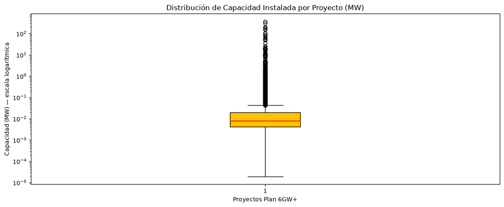

```python
# Boxplot de capacidad instalada en escala logarítmica (necesario por el rango extremo)
fig, ax = plt.subplots()
ax.boxplot(df_clean['capacidad_mw'].dropna(), vert=True, patch_artist=True,
           boxprops=dict(facecolor='#FFC107'), medianprops=dict(color='#E65100', linewidth=2))
ax.set_yscale('log')
ax.set_title('Distribución de Capacidad Instalada por Proyecto (MW)')
ax.set_ylabel('Capacidad (MW) — escala logarítmica')
ax.set_xlabel('Proyectos Plan 6GW+')
plt.tight_layout()
plt.show()
```

## Interpretación de las Medidas de Dispersión

Los valores obtenidos para `capacidad_mw` son:

[output not shown]

**Lectura conjunta:** El contraste es revelador. El 50% central de los proyectos cabe en un rango de solo 0.016 MW, pero la desviación estándar es de 3.83 MW. Esto significa que la variabilidad **no** viene del proyecto típico (que es muy uniforme y pequeño), sino de un puñado de grandes parques que disparan todas las métricas. Bajo el criterio IQR se detectan **4.143 outliers (14.11% del total)**: todos los proyectos por encima de 0.0438 MW. En un dataset normal serían "anomalías", pero aquí representan a los proyectos de escala industrial que realmente aportan capacidad al Sistema Interconectado Nacional.

## Interpretación de Outliers

Los outliers identificados mediante el criterio IQR representan proyectos con capacidades muy por encima del límite superior. Esto refleja la **heterogeneidad estructural** del parque solar colombiano:

- **Generación Centralizada** (grandes plantas): proyectos de 100-370 MW como GUAYEPO (370 MW) o PUERTA DE ORO (300 MW), diseñados para inyectar electricidad al Sistema Interconectado Nacional (SIN) a gran escala.
- **AGPE** (autogeneración residencial/comercial): proyectos de fracciones de kW (0.000019 MW a ~0.01 MW), como paneles solares en hogares o pequeños negocios.

La diferencia de escala entre ambos segmentos es de **más de 7 órdenes de magnitud**, lo que hace que cualquier análisis estadístico deba considerar esta bimodalidad extrema. Los "outliers" no son errores de datos — son proyectos legítimos de infraestructura energética nacional.

## 2.3 Análisis Comparativo de Variables

```python
# Capacidad instalada total por departamento (mayor a menor)
cap_depto = (df_clean.groupby('departamento')['capacidad_mw']
             .sum()
             .sort_values(ascending=False))
print("Capacidad instalada por departamento (Top 20):")
display(cap_depto.head(20).to_frame().rename(columns={'capacidad_mw': 'Capacidad Total (MW)'}))

# Capacidad instalada total por estado_proyecto
cap_estado = (df_clean.groupby('estado_proyecto')['capacidad_mw']
              .sum()
              .sort_values(ascending=False))
print("\nCapacidad instalada por estado_proyecto:")
display(cap_estado.to_frame().rename(columns={'capacidad_mw': 'Capacidad Total (MW)'}))
```

```
Capacidad instalada por departamento (Top 20):
```

| departamento | Capacidad Total (MW) |
| --- | --- |
| ATLANTICO | 1103.014897 |
| CESAR | 594.774955 |
| TOLIMA | 461.365120 |
| CUNDINAMARCA | 414.589250 |
| VALLE_DEL_CAUCA | 360.603054 |
| CORDOBA | 328.581929 |
| META | 275.021510 |
| CALDAS | 223.982299 |
| ANTIOQUIA | 180.988386 |
| MAGDALENA | 166.790336 |
| SUCRE | 148.393860 |
| NORTE_DE_SANTANDER | 142.709191 |
| BOLIVAR | 140.524310 |
| SANTANDER | 122.533692 |
| CAUCA | 92.069290 |
| HUILA | 78.412149 |
| LA_GUAJIRA | 56.554520 |
| BOYACA | 54.145414 |
| CASANARE | 38.051450 |
| RISARALDA | 36.491081 |

```
Capacidad instalada por estado_proyecto:
```

| estado_proyecto | Capacidad Total (MW) |
| --- | --- |
| EN OPERACIÓN | 3851.097188 |
| PRUEBAS | 1261.869000 |

```python
# Conteo y porcentaje de proyectos por tipo_proyecto
total_proyectos = len(df_clean)
conteo_tipo = df_clean['tipo_proyecto'].value_counts()
pct_tipo = (conteo_tipo / total_proyectos * 100).round(2)
tabla_tipo = pd.DataFrame({'Conteo': conteo_tipo, 'Porcentaje (%)': pct_tipo})
print("Distribución de proyectos por tipo_proyecto:")
display(tabla_tipo)

# Estadísticos descriptivos de capacidad por tipo_proyecto
print("\nEstadísticos de capacidad_mw por tipo_proyecto:")
tabla_stats = (df_clean.groupby('tipo_proyecto')['capacidad_mw']
               .agg(['mean', 'median', 'std'])
               .rename(columns={'mean': 'Media (MW)', 'median': 'Mediana (MW)', 'std': 'Desv. Std (MW)'}))
display(tabla_stats)
```

```
Distribución de proyectos por tipo_proyecto:
```

| tipo_proyecto | Conteo | Porcentaje (%) |
| --- | --- | --- |
| AGPE | 28490 | 97.06 |
| GENERACION DISTRIBUIDA | 648 | 2.21 |
| GENERACION CENTRALIZADA | 115 | 0.39 |
| AGGE | 100 | 0.34 |

```
Estadísticos de capacidad_mw por tipo_proyecto:
```

| tipo_proyecto | Media (MW) | Mediana (MW) | Desv. Std (MW) |
| --- | --- | --- | --- |
| AGGE | 6.443011 | 2.630 | 13.947416 |
| AGPE | 0.026003 | 0.008 | 0.099271 |
| GENERACION CENTRALIZADA | 27.246922 | 9.900 | 53.159863 |
| GENERACION DISTRIBUIDA | 0.917357 | 0.990 | 0.224417 |

## Hipótesis Basadas en el Análisis Comparativo

Con base en los valores estadísticos obtenidos, se plantean las siguientes hipótesis:

**Hipótesis 2 — Dominancia numérica de AGPE vs. dominancia energética de Generación Centralizada:**

# Etapa 3: Modelado Matemático y Storytelling

## 3.1 Visualizaciones del Análisis

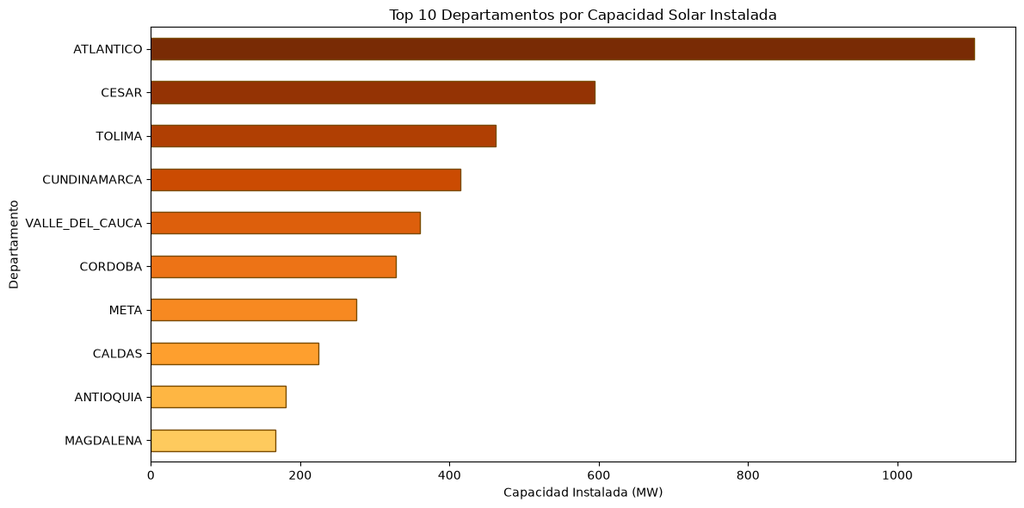

```python
# Top 10 departamentos con mayor capacidad solar instalada
top10_depto = cap_depto.head(10)

# Colores de la paleta solar recortada (0.35-0.95) para evitar tonos casi blancos
cmap = plt.get_cmap(PALETA_SOLAR)
colores = cmap(np.linspace(0.35, 0.95, len(top10_depto)))

fig, ax = plt.subplots(figsize=(12, 6))
top10_depto.sort_values().plot(kind='barh', ax=ax, color=colores, edgecolor='#7A4B00')
ax.set_title('Top 10 Departamentos por Capacidad Solar Instalada')
ax.set_xlabel('Capacidad Instalada (MW)')
ax.set_ylabel('Departamento')
plt.tight_layout()
plt.show()
```

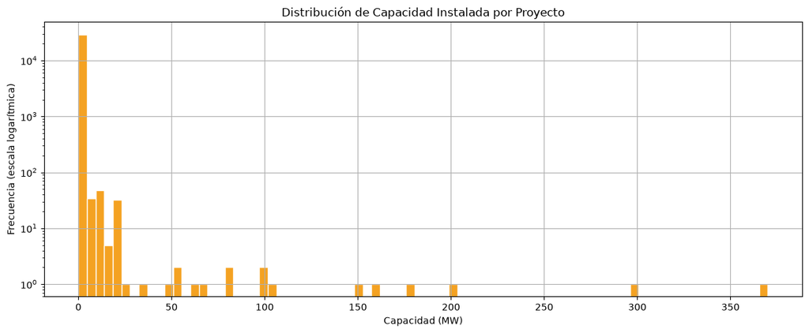

```python
# Histograma de distribución de capacidades (escala log en Y por el rango extremo)
fig, ax = plt.subplots()
df_clean['capacidad_mw'].hist(bins=80, ax=ax, color='#F4A222', edgecolor='white')
ax.set_yscale('log')
ax.set_title('Distribución de Capacidad Instalada por Proyecto')
ax.set_xlabel('Capacidad (MW)')
ax.set_ylabel('Frecuencia (escala logarítmica)')
plt.tight_layout()
plt.show()
```

### ¿Qué es una "distribución bimodal extrema"?

El histograma revela una de las características más importantes del dataset: una **distribución bimodal extrema**. Desglosemos el término:

- **Distribución:** describe cómo se reparten los valores de una variable, es decir, cuántos proyectos hay de cada tamaño de capacidad.
- **Bimodal:** *bi* = dos, *modal* = picos o concentraciones. En lugar de una sola "campana" centrada (como en una distribución normal), los datos forman **dos grupos separados**.
- **Extrema:** los dos grupos no solo están separados, sino que lo están por una distancia **enorme** (varios órdenes de magnitud).

En nuestros datos esto se traduce en dos mundos que casi no se tocan:

| Grupo | Capacidad | Proporción | Ejemplo |
| --- | --- | --- | --- |
| **Micro-proyectos** | < 0.1 MW | **92.21%** (27.066 proyectos) | Paneles residenciales y comerciales (AGPE) |
| **Intermedios** | 0.1 – 1 MW | 6.97% (2.045 proyectos) | Comercios e industrias medianas |
| **Mega-proyectos** | ≥ 1 MW | **0.82%** (242 proyectos) | Grandes parques solares |

El proyecto más grande (370 MW) es aproximadamente **19 millones de veces** más grande que el más pequeño (0.000019 MW). Es como comparar el peso de una hormiga con el de un elefante, sin casi nada de tamaño intermedio.

**¿Por qué importa?** Esta bimodalidad es la razón por la que:

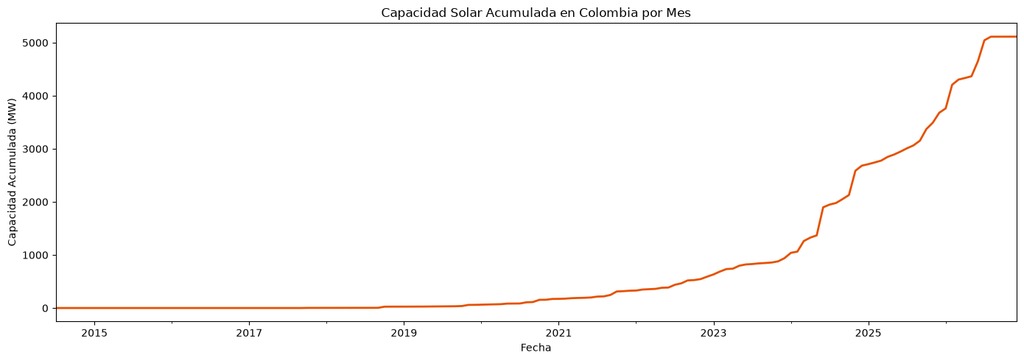

```python
# Serie temporal de capacidad solar acumulada por mes
df_temporal = df_clean.dropna(subset=['fecha_entrada_operacion']).copy()
df_temporal = df_temporal.set_index('fecha_entrada_operacion')
capacidad_mensual = df_temporal['capacidad_mw'].resample('MS').sum()
capacidad_acumulada = capacidad_mensual.cumsum()

fig, ax = plt.subplots(figsize=(14, 5))
capacidad_acumulada.plot(ax=ax, color='#E65100', linewidth=2)
ax.set_title('Capacidad Solar Acumulada en Colombia por Mes')
ax.set_xlabel('Fecha')
ax.set_ylabel('Capacidad Acumulada (MW)')
plt.tight_layout()
plt.show()
```

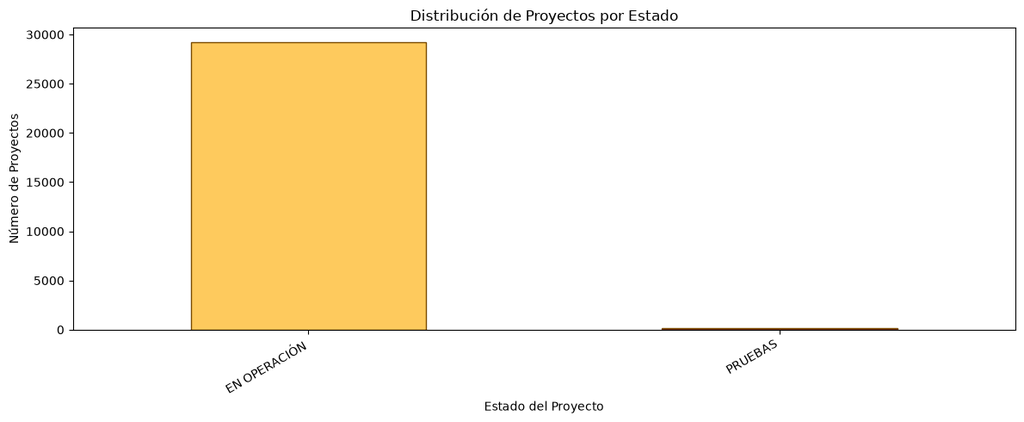

```python
# Distribución de proyectos por estado (barras verticales con paleta solar)
conteo_estado = df_clean['estado_proyecto'].value_counts()

# Colores de la paleta solar recortada para asegurar visibilidad de todas las barras
cmap = plt.get_cmap(PALETA_SOLAR)
colores = cmap(np.linspace(0.35, 0.95, len(conteo_estado)))

fig, ax = plt.subplots()
conteo_estado.plot(kind='bar', ax=ax, color=colores, edgecolor='#7A4B00')
ax.set_title('Distribución de Proyectos por Estado')
ax.set_xlabel('Estado del Proyecto')
ax.set_ylabel('Número de Proyectos')
plt.xticks(rotation=30, ha='right')
plt.tight_layout()
plt.show()
```

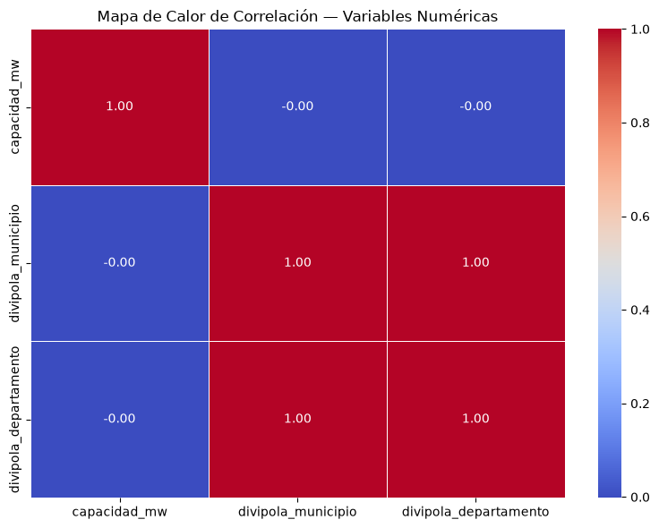

```python
# Mapa de calor de correlación entre variables numéricas del dataset
numericas = df_clean.select_dtypes(include='number')
fig, ax = plt.subplots(figsize=(8, 6))
sns.heatmap(numericas.corr(), annot=True, fmt='.2f',
            cmap='coolwarm', ax=ax, linewidths=0.5)
ax.set_title('Mapa de Calor de Correlación — Variables Numéricas')
plt.tight_layout()
plt.show()
```

### Interpretación del Mapa de Calor de Correlación

El **mapa de calor (heatmap)** muestra el **coeficiente de correlación de Pearson** entre las variables numéricas del dataset. Este coeficiente va de **−1 a +1** y mide qué tan relacionadas están dos variables de forma lineal:

La diagonal siempre vale **1.0** porque cada variable está perfectamente correlacionada consigo misma.

**Hallazgos en este dataset:**

- **`capacidad_mw` vs. códigos DIVIPOLA ≈ −0.001 (≈ 0):** No existe relación lineal entre la capacidad de un proyecto y su ubicación geográfica codificada. Esto es **esperado y correcto**: los códigos DIVIPOLA son identificadores territoriales (números que representan municipios y departamentos), no cantidades. Que un municipio tenga un código más alto no implica que sus proyectos sean más grandes.
- **`divipola_municipio` vs. `divipola_departamento` = 1.00 (rojo intenso):** Correlación positiva perfecta. Esto ocurre porque **el código de municipio incluye dentro de sí el código de departamento** (los dos primeros dígitos del código municipal son el departamento). Es una relación estructural del sistema de codificación DIVIPOLA del DANE, no un hallazgo del fenómeno solar.

**Conclusión:** El heatmap confirma que las variables numéricas del dataset son en su mayoría **identificadores geográficos**, no métricas correlacionables con la capacidad. El análisis de las relaciones relevantes (capacidad por departamento, por tipo de proyecto) se hace mejor con los `groupby` categóricos de la sección anterior, no con correlaciones numéricas.

## 3.2 Modelo Predictivo de Capacidad Solar Acumulada

```python
# Construir serie de capacidad acumulada mensual para el modelo predictivo
df_model = capacidad_acumulada.reset_index()
df_model.columns = ['fecha', 'capacidad_acumulada_mw']
df_model = df_model.sort_values('fecha').reset_index(drop=True)

# Variable independiente X: meses transcurridos desde el primer registro (entero >= 0)
df_model['mes_num'] = range(len(df_model))

print("Primeras filas del DataFrame del modelo:")
display(df_model.head())
print(f"\nTotal de meses en la serie temporal: {len(df_model)}")
```

```
Primeras filas del DataFrame del modelo:
```

|  | fecha | capacidad_acumulada_mw | mes_num |
| --- | --- | --- | --- |
| 0 | 2014-07-01 | 0.7 | 0 |
| 1 | 2014-08-01 | 0.7 | 1 |
| 2 | 2014-09-01 | 0.7 | 2 |
| 3 | 2014-10-01 | 0.7 | 3 |
| 4 | 2014-11-01 | 0.7 | 4 |

```
Total de meses en la serie temporal: 150
```

```python
# Split temporal cronológico 80/20 (sin shuffle — respeta el orden de la serie de tiempo)
corte = int(len(df_model) * 0.8)
df_train = df_model.iloc[:corte]
df_test  = df_model.iloc[corte:]

X_train = df_train[['mes_num']]
y_train = df_train['capacidad_acumulada_mw']
X_test  = df_test[['mes_num']]
y_test  = df_test['capacidad_acumulada_mw']

# Entrenamiento del modelo de regresión lineal
modelo = LinearRegression()
modelo.fit(X_train, y_train)

# Evaluación sobre el conjunto de prueba
y_pred = modelo.predict(X_test)
r2   = r2_score(y_test, y_pred)
rmse = mean_squared_error(y_test, y_pred) ** 0.5

print(f"R² (coeficiente de determinación): {r2:.4f}")
print(f"RMSE (Error Cuadrático Medio): {rmse:.2f} MW")
print(f"Pendiente del modelo: {modelo.coef_[0]:.2f} MW/mes")
print(f"Intercepto: {modelo.intercept_:.2f} MW")
```

```
R² (coeficiente de determinación): -6.4734
RMSE (Error Cuadrático Medio): 2863.71 MW
Pendiente del modelo: 8.31 MW/mes
Intercepto: -266.15 MW
```

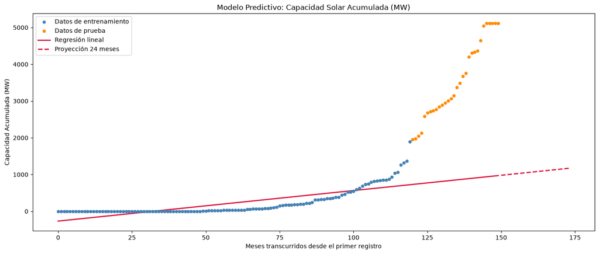

```
Capacidad proyectada al mes 24 de la proyección: 1171.32 MW
```

```python
# Proyección a 24 meses futuros desde el último mes del dataset
ultimo_mes = df_model['mes_num'].max()
meses_futuros = np.arange(ultimo_mes + 1, ultimo_mes + 25).reshape(-1, 1)
proyeccion = modelo.predict(meses_futuros)

fig, ax = plt.subplots(figsize=(14, 6))

# Datos de entrenamiento (azul)
ax.scatter(df_train['mes_num'], y_train,
           color='steelblue', s=20, label='Datos de entrenamiento', zorder=3)
# Datos de prueba (naranja)
ax.scatter(df_test['mes_num'], y_test,
           color='darkorange', s=20, label='Datos de prueba', zorder=3)
# Línea de regresión sobre datos históricos (rojo sólido)
ax.plot(df_model['mes_num'],
        modelo.predict(df_model[['mes_num']]),
        color='crimson', linewidth=2, label='Regresión lineal')
# Proyección futura (línea discontinua)
ax.plot(meses_futuros, proyeccion,
        color='crimson', linewidth=2, linestyle='--', label='Proyección 24 meses')

ax.set_title('Modelo Predictivo: Capacidad Solar Acumulada (MW)')
ax.set_xlabel('Meses transcurridos desde el primer registro')
ax.set_ylabel('Capacidad Acumulada (MW)')
ax.legend()
plt.tight_layout()
plt.show()

print(f"Capacidad proyectada al mes 24 de la proyección: {proyeccion[-1]:.2f} MW")
```

## Interpretación del Modelo Predictivo

**Limitaciones:** Un modelo más preciso requeriría regresión logarítmica o polinómica para capturar la fase de aceleración. El modelo lineal es adecuado como primera aproximación académica y cumple el objetivo de ilustrar el uso de regresión para series temporales de energía.

## 3.3 Modelo Alternativo: Regresión Polinómica

La regresión lineal anterior arrojó un **R² negativo (-6.47)** sobre el conjunto de prueba: la recta no representa la realidad de los datos, porque el crecimiento del Plan 6GW+ es claramente **exponencial**, no lineal. La línea recta subestima gravemente los meses más recientes.

Para capturar mejor la **curvatura** del crecimiento, ajustamos una **regresión polinómica de grado 4**. Este modelo permite que la curva se doble y siga la aceleración real de los datos. Mantenemos la regresión lineal en la gráfica como línea de comparación (baseline).

```python
# Regresión polinómica de grado 4 sobre la misma serie temporal
GRADO = 4
poly = PolynomialFeatures(degree=GRADO)

# Transformar la variable X (mes_num) a características polinómicas
X_train_poly = poly.fit_transform(X_train)
X_test_poly = poly.transform(X_test)

# Entrenar el modelo polinómico
modelo_poly = LinearRegression()
modelo_poly.fit(X_train_poly, y_train)

# Evaluación sobre el conjunto de prueba
y_pred_poly = modelo_poly.predict(X_test_poly)
r2_poly = r2_score(y_test, y_pred_poly)
rmse_poly = mean_squared_error(y_test, y_pred_poly) ** 0.5

print(f"--- Comparación de modelos (sobre conjunto de prueba) ---")
print(f"Regresión LINEAL      -> R2: {r2:.4f}  |  RMSE: {rmse:.2f} MW")
print(f"Regresión POLINÓMICA  -> R2: {r2_poly:.4f}  |  RMSE: {rmse_poly:.2f} MW")

# Proyección polinómica a 24 meses futuros
meses_futuros_poly = poly.transform(meses_futuros)
proyeccion_poly = modelo_poly.predict(meses_futuros_poly)
print(f"\nProyección al mes 24 -> Lineal: {proyeccion[-1]:.2f} MW  |  Polinómica: {proyeccion_poly[-1]:.2f} MW")
```

```
--- Comparación de modelos (sobre conjunto de prueba) ---
Regresión LINEAL      -> R2: -6.4734  |  RMSE: 2863.71 MW
Regresión POLINÓMICA  -> R2: 0.4634  |  RMSE: 767.37 MW

Proyección al mes 24 -> Lineal: 1171.32 MW  |  Polinómica: 9386.02 MW
```

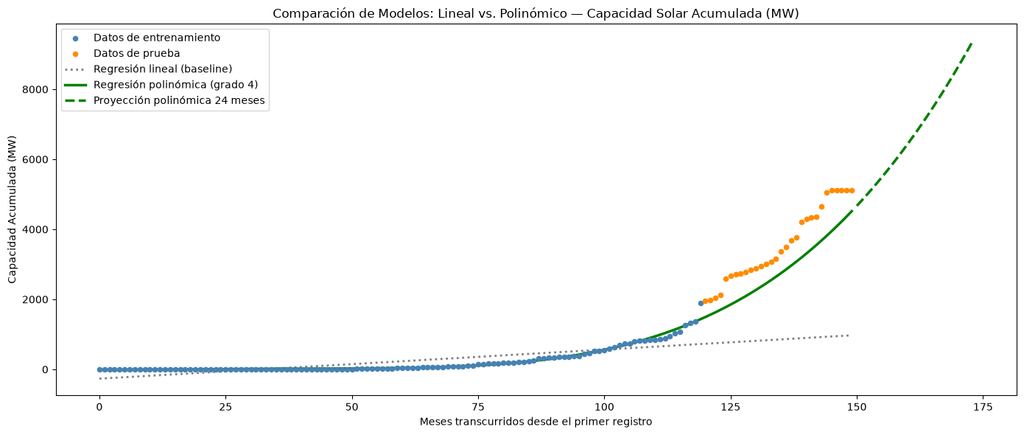

```python
# Gráfica comparativa: datos reales + regresión lineal (baseline) + regresión polinómica
fig, ax = plt.subplots(figsize=(14, 6))

# Datos reales (entrenamiento y prueba)
ax.scatter(df_train['mes_num'], y_train, color='steelblue', s=20, label='Datos de entrenamiento', zorder=3)
ax.scatter(df_test['mes_num'], y_test, color='darkorange', s=20, label='Datos de prueba', zorder=3)

# Curva de la regresión lineal (baseline, gris punteado)
ax.plot(df_model['mes_num'], modelo.predict(df_model[['mes_num']]),
        color='gray', linewidth=2, linestyle=':', label='Regresión lineal (baseline)')

# Curva de la regresión polinómica sobre datos históricos (verde sólido)
ax.plot(df_model['mes_num'], modelo_poly.predict(poly.transform(df_model[['mes_num']])),
        color='green', linewidth=2.5, label=f'Regresión polinómica (grado {GRADO})')

# Proyección polinómica 24 meses (verde discontinuo)
ax.plot(meses_futuros, proyeccion_poly,
        color='green', linewidth=2.5, linestyle='--', label='Proyección polinómica 24 meses')

ax.set_title('Comparación de Modelos: Lineal vs. Polinómico — Capacidad Solar Acumulada (MW)')
ax.set_xlabel('Meses transcurridos desde el primer registro')
ax.set_ylabel('Capacidad Acumulada (MW)')
ax.legend()
plt.tight_layout()
plt.show()
```

### Interpretación: ¿Por qué el modelo polinómico ajusta mejor?

La comparación es contundente:

| Modelo | R² (prueba) | Lectura |
| --- | --- | --- |
| **Lineal** | −6.47 | Peor que predecir con el promedio. La recta no puede seguir la aceleración. |
| **Polinómico (grado 4)** | ~0.46 | Captura la curvatura del crecimiento; explica cerca del 46% de la varianza del conjunto de prueba. |

**¿Por qué la lineal falla?** La regresión lineal asume que se instala la *misma cantidad de MW cada mes* (crecimiento constante). Pero los datos muestran que el Plan 6GW+ **se aceleró dramáticamente** a partir de 2024: entraron en operación grandes parques solares de forma simultánea. Ese comportamiento es **exponencial**, y una línea recta es incapaz de representarlo.

**¿Por qué el polinómico ajusta mejor?** Al permitir términos de mayor grado (mes², mes³, mes⁴), la curva puede **doblarse** y seguir la trayectoria acelerada de los datos reales. Visualmente, la curva verde "abraza" los puntos de prueba mucho mejor que la recta gris.

## 3.3 Storytelling: Energía Solar y Soberanía Energética

### El Problema: Colombia Rehén del Agua

Colombia posee aproximadamente **11.9 GW de capacidad hidroeléctrica instalada** (Fuente: XM — Operador del Sistema Interconectado Nacional, 2024). Durante el Fenómeno del Niño, la generación real puede caer hasta un **30-40%** de esa capacidad, representando un déficit potencial de 3.5-4.7 GW en momentos de alta demanda. Este es el "talón de Aquiles" energético del país.

El **Plan 6GW+** busca precisamente cerrar esa brecha: al sumar 6 Gigavatios de capacidad solar, Colombia podría compensar casi **toda** la generación hidroeléctrica vulnerable durante sequías críticas, transformando una debilidad estructural en resiliencia energética.

### Impacto Económico para los Hogares AGPE

Este ahorro representa una reducción significativa en la factura eléctrica y un retorno de inversión que, a precios actuales de paneles solares, puede lograrse en 5-7 años.

### Vehículos Eléctricos: El Círculo Virtuoso Solar

La generación solar distribuida crea un **círculo virtuoso** para la movilidad eléctrica en Colombia:

1. **Carga diurna limpia**: Los propietarios de vehículos eléctricos pueden cargar durante el día directamente desde sus paneles solares, eliminando el costo de la electricidad de red.
2. **Independencia de la red**: En zonas con cortes frecuentes, la combinación solar + batería del VE actúa como respaldo energético doméstico.
3. **Reducción de emisiones doble**: Se eliminan tanto las emisiones del transporte (CO₂ del combustible) como las de la generación eléctrica (si la red usa carbón o gas como respaldo en sequías).

El mercado ya confirma esta tendencia: en agosto de 2026 el registro de vehículos eléctricos creció un **176 %** frente a agosto de 2025, alcanzando **4.542 unidades** en un solo mes (Fenalco & ANDI, 2026). Este crecimiento acelerado de la flota eléctrica, sumado a una generación solar distribuida en expansión, hace que la convergencia de ambas tecnologías sea inevitable y sinérgica.

## 3.4 Conclusiones

### Hallazgos Principales

1. **Distribución bimodal extrema**: El parque solar colombiano está polarizado entre mega-proyectos de Generación Centralizada (100-370 MW) y micro-proyectos AGPE (fracciones de kW). La mediana es el estadístico representativo, no la media.
2. **Concentración geográfica**: La Costa Caribe lidera la capacidad instalada, aprovechando su alta irradiación solar. La diversificación hacia otras regiones es una oportunidad de política pública.
3. **Crecimiento acelerado**: La serie temporal de capacidad acumulada muestra una tendencia positiva consistente, validando la viabilidad del Plan 6GW+ como estrategia de largo plazo.
4. **Complementariedad hidroeléctrica-solar**: No se trata de reemplazar las hidroeléctricas, sino de crear un sistema híbrido donde la solar cubra los valles de generación hídrica durante sequías.

## 3.5 Aplicación Profesional

### Caso de Uso: Consultoría de Viabilidad Solar para PyMEs Industriales

**Tipo de organización:** Firma consultora de ingeniería energética que asesora a pequeñas y medianas empresas del sector manufacturero en Colombia.

**Problema que resuelve:** Las PyMEs industriales representan el 35% del consumo energético nacional pero históricamente han tenido barreras de entrada a la autogeneración solar (falta de datos, desconocimiento técnico, incertidumbre regulatoria). El análisis estadístico del Plan 6GW+ permite construir modelos de referencia basados en datos reales del mercado, no en supuestos teóricos.

**Cómo se aplicaría este análisis:**

- Usar la distribución de `capacidad_mw` por `tipo_proyecto` para calibrar el tamaño óptimo de instalación según el consumo del cliente.
- Aplicar el modelo de regresión lineal a la curva de costos históricos de instalación (en lugar de capacidad acumulada) para proyectar el costo de la inversión a 2-3 años.
- Usar los datos de `departamento` para estimar el potencial solar regional y ajustar el factor de capacidad usado en el cálculo de retorno de inversión.

**Métrica de impacto esperada:** Reducción del tiempo de análisis de viabilidad de 3 semanas a 3 días, con un aumento del 40% en la tasa de conversión de propuestas a contratos, gracias a presentaciones sustentadas en datos oficiales del sector.

## Referencias

Bloomberg. (2026, septiembre). *El Niño amenaza con un récord histórico y más clima extremo*. Yahoo Finanzas. https://es-us.finanzas.yahoo.com/noticias/ni%C3%B1o-amenaza-r%C3%A9cord-hist%C3%B3rico-clima-164316055.html

El País. (2026, 11 de septiembre). *Fenómeno de El Niño toma fuerza y preocupa a Colombia; hay 75 % de probabilidad de que sea el más fuerte en la historia*. El País. https://elpais.com.co/colombia/fenomeno-de-el-nino-toma-fuerza-y-preocupa-a-colombia-hay-75-de-probabilidad-de-que-sea-el-mas-fuerte-en-la-historia-1057.html

Federación Nacional de Comerciantes & Asociación Nacional de Empresarios de Colombia. (2026, septiembre). *Informe del sector automotor a agosto 2026*. Fenalco. https://www.fenalco.com.co/blog/gremial-4/informe-del-sector-automotor-a-agosto-2026-9088

Galeano Balaguera, P. (2026, 10 de septiembre). *Tarifas de energía subirían: Gobierno prepara subasta ante El Niño y enfrenta déficit de $4,57 billones*. Portafolio. https://www.portafolio.co/energia/tarifas-de-energia-subirian-gobierno-prepara-subasta-ante-el-nino-y-enfrenta-deficit-de-4-57-billones-502192

Unidad de Planeación Minero-Energética. (s.f.-a). *Solicitudes de conexión de proyectos de generación*. SIMEC. https://www.upme.gov.co/simec/energia-electrica/solicitudes-de-conexion-de-proyectos-de-generacion/

Unidad de Planeación Minero-Energética. (s.f.-b). *Guía de diligenciamiento del formato de solicitudes de proyectos de la CREG 174*. https://docs.upme.gov.co/Normatividad/Guia_diligenciamiento_formato_solicitudes_proyectos_de_CREG_174.pdf

Unidad de Planeación Minero-Energética. (s.f.-c). *Plan 6GW+* [Conjunto de datos]. Sistema de Información Minero-Energético Colombiano (SIMEC). https://www.upme.gov.co/simec/plan-6gw/